# 1. Abrindo Bibliotecas

### Bibliotecas genérias

```python
import numpy as np
import pandas as pd
import matplotlib.pyplot as plt
import seaborn as sns

%matplotlib inline
```

### As seguintes bibliotecas serão alvo do nosso estudo:

```python
from pandas_datareader import data
import quandl
import cufflinks as cf
import yahoofinancials
```

A intenção desse estudo é trazer dados úteis que podem esclarecer um pouco mais o que aconteceu com GME na situação do short squeeze

Conceito de Data Hedging https://www.investopedia.com/terms/d/deltahedging.asp

O que é o Short Interest?

https://www.investopedia.com/articles/01/082201.asp

# 2. Cufflinks

```python
cf.set_config_file(theme='pearl',sharing='public',offline=True)
```

```python
gme = data.DataReader('GME', data_source='yahoo', start='2020-12-01')
```

```python
gme.iplot(kind="candle",
                          keys=["Open", "High", "Low", "Close"],
                          rangeslider=True
                          )
```

[interactive chart not shown]

```python
qf=cf.QuantFig(gme,title='First Quant Figure',legend='top',name='GS')
qf.add_bollinger_bands()
qf.iplot()
```

[interactive chart not shown]

```python
qf=cf.QuantFig(gme,title='First Quant Figure',legend='top',name='GS')
qf.add_bollinger_bands()
qf.add_volume()
qf.iplot()
```

[interactive chart not shown]

```python
qf=cf.QuantFig(gme,title='GME Quant Figure',legend='top',name='GS')

qf.add_adx()
qf.add_cci()
qf.add_dmi()
qf.add_ema()

qf.iplot()
```

[interactive chart not shown]

# 3. Quandl

A Quandl será usada aqui para capturar dados do Volume de Ações Vendidas (Short Sale Volume) obtidos da FINRA.

O que é isso?

Seguindo uma norma da SEC, a FINRA disponibiliza publicamente dados diários do volume de papéis vendidtos (short) de negociações de ações não listadas em exchanges (over the counter securities), reportadas ao OTC Reporting Facility.

Esses dados fornecem o volume agregado por ação de todas as negociações vendidas executadas e reportadas à OFR durante o horário de pregão.

Para saber mais sobre os dados: https://www.finra.org/filing-reporting/orf/orf-regulation-sho

Para saber mais sobre a OFR: https://www.finra.org/filing-reporting/over-the-counter-reporting-facility-orf#:~:text=The%20OTC%20Reporting%20Facility%20(ORF,dissemination%20of%20last%20sale%20reports.

Documentação da FINRA na Quandl

https://www.quandl.com/data/FINRA/FNYX_GME-FINRA-NYSE-TRF-Short-Interest-GME

Agora que você já obteve seu token de acesso a Quandl, vamos salvá-lo num arquivo .txt de nome "senha"

A seguir, vamos abrir esse arquivo, e chamar de "token" o seu conteúdo

Chave da Quandl vem num formato parecido com esse:

```python
f = open("senha.txt", "r")

token = f.read()
```

```python
token
```

```
'77TfLxTY9XzxycV_uzSe'
```

```python
quandl.ApiConfig.api_key = token
```

```python
quandl.ApiConfig.api_key = "77TfLxTY9XzxycV_uzSe"
```

```python
finra = quandl.get("FINRA/FNYX_GME", trim_start = "2020-08-01")
```

```python
finra.head()
```

| Date | ShortVolume | ShortExemptVolume | TotalVolume |
| --- | --- | --- | --- |
| 2020-08-03 | 28678.0 | 0.0 | 167741.0 |
| 2020-08-04 | 434953.0 | 0.0 | 1411726.0 |
| 2020-08-05 | 205375.0 | 0.0 | 459608.0 |
| 2020-08-06 | 69919.0 | 0.0 | 199033.0 |
| 2020-08-07 | 143366.0 | 0.0 | 339322.0 |

# Explicar

- O que é a FINRA
- O que são Market Makers
- O que é hedge
- O que são calls - opções de compra
- Falar que nos EUA a margem precisa ser respeitada, se não o vendido (short seller) precisa comprar o papel
- O que é o short interest?

```python
# Procurar dados de compra do papel e hold por parte dos acionistas

# Uma opção é mostrar isso através da diminuição do float geral do papel

# Quanto do free float passou a ser 'segurado' pelos acionistas?
```

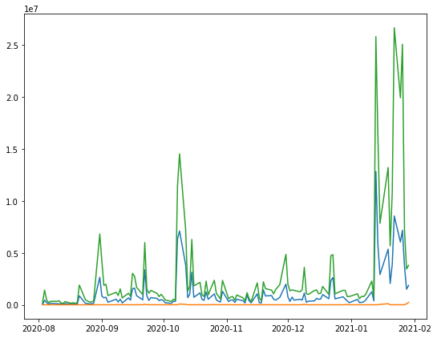

```python
finra = quandl.get("FINRA/FNYX_GME", trim_start = "2020-08-01")
plt.figure(figsize=(9,7))
plt.plot(finra)
```

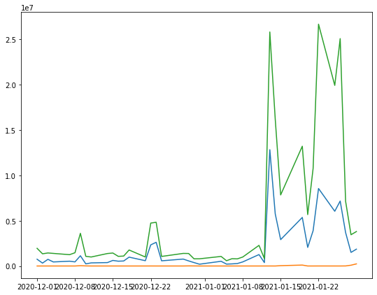

```python
finra = quandl.get("FINRA/FNYX_GME", trim_start = "2020-12-01")
plt.figure(figsize=(9,7))
plt.plot(finra)
```

Exemplo de como verificar cotação vs. volume

https://www.reddit.com/r/wallstreetbets/comments/l81luf/hey_sec_heres_your_market_manipulation_rh_working/

OBS.: Nesse ponto tentar pegar os dados de short interest de vários outros papéis e compará-los no mesmo gráfico

# 4. yahoofinancials

A biblioteca *yahoofinancials* é uma das melhores formas de se obter dados fundamentalistas direto do Yahoo Finance, em poucas linhas de código

A grande desvantagem é que os dados são retornados em elementos JSON, que por natureza são difcíceis de se realizar o parse, e consequentemente torna o processamento e a análise posterior um pouco mais difícil

Referências para trabalhar com JSONs

https://towardsdatascience.com/how-to-parse-json-data-with-python-pandas-f84fbd0b1025

https://stackoverflow.com/questions/16729574/how-to-get-a-value-from-a-cell-of-a-dataframe

https://stackoverflow.com/questions/42354001/python-json-object-must-be-str-bytes-or-bytearray-not-dict

https://stackoverflow.com/questions/21104592/json-to-pandas-dataframe

```python
! pip install yahoofinancials
```

```python
from yahoofinancials import YahooFinancials

ticker = 'GME'
yahoo_financials = YahooFinancials(ticker)
```

### Vamos verificar os dados anuais pra ver se bate com o Yahoo Finance

```python
balance_sheet_data_qt = yahoo_financials.get_financial_stmts('quarterly', 'balance')
income_statement_data_qt = yahoo_financials.get_financial_stmts('quarterly', 'income')
all_statement_data_qt =  yahoo_financials.get_financial_stmts('quarterly', ['income', 'cash', 'balance'])
GME_earnings_data = yahoo_financials.get_stock_earnings_data()
GME_net_income = yahoo_financials.get_net_income()
```

```python
balance_sheet_data_qt = yahoo_financials.get_financial_stmts('annual', 'balance')
income_statement_data_qt = yahoo_financials.get_financial_stmts('annual', 'income')

# Outra opção de obter o dado de statment é usando todos os statements: income, cash e balance
all_statement_data_qt =  yahoo_financials.get_financial_stmts('annual', ['income', 'cash', 'balance'])

GME_earnings_data = yahoo_financials.get_stock_earnings_data()
GME_net_income = yahoo_financials.get_net_income()
```

Vamos fazer um teste: que tipo são esses dados nos outputs?

```python
type(all_statement_data_qt)
```

```
dict
```

```python
all_statement_data_qt
```

```
{'incomeStatementHistory': {'GME': [{'2020-02-01': {'researchDevelopment': None,
     'effectOfAccountingCharges': None,
     'incomeBeforeTax': -426800000,
     'minorityInterest': None,
     'netIncome': -470900000,
     'sellingGeneralAdministrative': 1893600000,
     'grossProfit': 1908700000,
     'ebit': 15100000,
     'operatingIncome': 15100000,
     'otherOperatingExpenses': None,
     'interestExpense': -38500000,
     'extraordinaryItems': None,
     'nonRecurring': None,
     'otherItems': None,
     'incomeTaxExpense': 37600000,
     'totalRevenue': 6466000000,
     'totalOperatingExpenses': 6450900000,
     'costOfRevenue': 4557300000,
     'totalOtherIncomeExpenseNet': -441900000,
     'discontinuedOperations': -6500000,
     'netIncomeFromContinuingOps': -464400000,
     'netIncomeApplicableToCommonShares': -470900000}},
   {'2019-02-02': {'researchDevelopment': None,
     'effectOfAccountingCharges': None,
     'incomeBeforeTax': -753100000,
     'minorityInterest': None,
     'netIncome': -673000000,
     'sellingGeneralAdministrative': 1997200000,
     'grossProfit': 2308100000,
     'ebit': 310900000,
     'operatingIncome': 310900000,
     'otherOperatingExpenses': None,
     'interestExpense': -56800000,
     'extraordinaryItems': None,
     'nonRecurring': None,
     'otherItems': None,
     'incomeTaxExpense': 41700000,
     'totalRevenue': 8285300000,
     'totalOperatingExpenses': 7974400000,
     'costOfRevenue': 5977200000,
```

[output cut: 195 more lines]

```
     'otherLiab': 145300000,
     'goodWill': 1725200000,
     'treasuryStock': -47300000,
     'otherAssets': 131800000,
     'cash': 669400000,
     'totalCurrentLiabilities': 1761500000,
     'deferredLongTermAssetCharges': 59000000,
     'otherStockholderEquity': -47300000,
     'propertyPlantEquipment': 471000000,
     'totalCurrentAssets': 2140700000,
     'netTangibleAssets': 21700000,
     'netReceivables': 220900000,
     'longTermDebt': 815000000,
     'inventory': 1121500000,
     'accountsPayable': 616600000}}]}}
```

Verifique que esses dados são do tipo "JSON", por isso vem no formato de dicionário. Por causa disso, teremos que trabalhar com métodos específicos para tratar JSON

As principais funções para se trabalhar com JSON são:

json.loads take a string as input and returns a dictionary as output.

json.dumps take a dictionary as input and returns a string as output.

Além disso, na package pandas, a função pd.json_normalize pega um JSON de input e transforma num pandas Data Frame de output

```python
import json
#data = json.dumps(data)
#data = json.loads(data)

incomeStatementHistory = pd.json_normalize(all_statement_data_qt['incomeStatementHistory'])
```

```python
incomeStatementHistory
```

|  | GME |
| --- | --- |
| 0 | [{'2020-02-01': {'researchDevelopment': None, ... |

```python
dictionary = incomeStatementHistory.iloc[0]

string = list(dictionary[[0]])

stringa = string[0]
```

```python
stringa
```

```
[{'2020-02-01': {'researchDevelopment': None,
   'effectOfAccountingCharges': None,
   'incomeBeforeTax': -426800000,
   'minorityInterest': None,
   'netIncome': -470900000,
   'sellingGeneralAdministrative': 1893600000,
   'grossProfit': 1908700000,
   'ebit': 15100000,
   'operatingIncome': 15100000,
   'otherOperatingExpenses': None,
   'interestExpense': -38500000,
   'extraordinaryItems': None,
   'nonRecurring': None,
   'otherItems': None,
   'incomeTaxExpense': 37600000,
   'totalRevenue': 6466000000,
   'totalOperatingExpenses': 6450900000,
   'costOfRevenue': 4557300000,
   'totalOtherIncomeExpenseNet': -441900000,
   'discontinuedOperations': -6500000,
   'netIncomeFromContinuingOps': -464400000,
   'netIncomeApplicableToCommonShares': -470900000}},
 {'2019-02-02': {'researchDevelopment': None,
   'effectOfAccountingCharges': None,
   'incomeBeforeTax': -753100000,
   'minorityInterest': None,
   'netIncome': -673000000,
   'sellingGeneralAdministrative': 1997200000,
   'grossProfit': 2308100000,
   'ebit': 310900000,
   'operatingIncome': 310900000,
   'otherOperatingExpenses': None,
   'interestExpense': -56800000,
   'extraordinaryItems': None,
   'nonRecurring': None,
   'otherItems': None,
   'incomeTaxExpense': 41700000,
   'totalRevenue': 8285300000,
   'totalOperatingExpenses': 7974400000,
   'costOfRevenue': 5977200000,
```

[output cut: 33 more lines]

```
   'ebit': 501300000,
   'operatingIncome': 501300000,
   'otherOperatingExpenses': None,
   'interestExpense': -53800000,
   'extraordinaryItems': None,
   'nonRecurring': None,
   'otherItems': None,
   'incomeTaxExpense': 124200000,
   'totalRevenue': 7965000000,
   'totalOperatingExpenses': 7463700000,
   'costOfRevenue': 5465100000,
   'totalOtherIncomeExpenseNet': -72600000,
   'discontinuedOperations': 48700000,
   'netIncomeFromContinuingOps': 304500000,
   'netIncomeApplicableToCommonShares': 353200000}}]
```

Se quisermos trabalhar com um trimestre ou ano específico, precisaremos filtrar, e só em seguida criar um data frame

```python
string_b = stringa[0]
```

```python
string_b
```

```
{'2020-02-01': {'researchDevelopment': None,
  'effectOfAccountingCharges': None,
  'incomeBeforeTax': -426800000,
  'minorityInterest': None,
  'netIncome': -470900000,
  'sellingGeneralAdministrative': 1893600000,
  'grossProfit': 1908700000,
  'ebit': 15100000,
  'operatingIncome': 15100000,
  'otherOperatingExpenses': None,
  'interestExpense': -38500000,
  'extraordinaryItems': None,
  'nonRecurring': None,
  'otherItems': None,
  'incomeTaxExpense': 37600000,
  'totalRevenue': 6466000000,
  'totalOperatingExpenses': 6450900000,
  'costOfRevenue': 4557300000,
  'totalOtherIncomeExpenseNet': -441900000,
  'discontinuedOperations': -6500000,
  'netIncomeFromContinuingOps': -464400000,
  'netIncomeApplicableToCommonShares': -470900000}}
```

Agora enfim podemos transformar isso num data frame e em seguida seguir com a análise

```python
string_df = pd.json_normalize(string_b['2020-02-01'])
```

```python
string_df
```

|  | researchDevelopment | effectOfAccountingCharges | incomeBeforeTax | minorityInterest | netIncome | sellingGeneralAdministrative | grossProfit | ebit | operatingIncome | otherOperatingExpenses | ... | nonRecurring | otherItems | incomeTaxExpense | totalRevenue | totalOperatingExpenses | costOfRevenue | totalOtherIncomeExpenseNet | discontinuedOperations | netIncomeFromContinuingOps | netIncomeApplicableToCommonShares |
| --- | --- | --- | --- | --- | --- | --- | --- | --- | --- | --- | --- | --- | --- | --- | --- | --- | --- | --- | --- | --- | --- |
| 0 | None | None | -426800000 | None | -470900000 | 1893600000 | 1908700000 | 15100000 | 15100000 | None | ... | None | None | 37600000 | 6466000000 | 6450900000 | 4557300000 | -441900000 | -6500000 | -464400000 | -470900000 |

1 rows × 22 columns

Uma outra forma mais fácil de obter todas as estatísticas principais de uma só vez:

```python
yahoo_financials = YahooFinancials('GME')
print(yahoo_financials.get_key_statistics_data())
```

```
{'GME': {'annualHoldingsTurnover': None, 'enterpriseToRevenue': 4.529, 'beta3Year': None, 'profitMargins': -0.053239997, 'enterpriseToEbitda': -180.657, '52WeekChange': 81.27848, 'morningStarRiskRating': None, 'forwardEps': -0.17, 'revenueQuarterlyGrowth': None, 'sharesOutstanding': 69747000, 'fundI…
```

```python
key_statistics = yahoo_financials.get_key_statistics_data()
```

Vamos transformar esse JSON em um data frame?

```python
key_statistics_df = pd.json_normalize(key_statistics['GME'])
```

```python
key_statistics_df.transpose()
```

|  | 0 |
| --- | --- |
| annualHoldingsTurnover | None |
| enterpriseToRevenue | 4.529 |
| beta3Year | None |
| profitMargins | -0.05324 |
| enterpriseToEbitda | -180.657 |
| 52WeekChange | 81.2785 |
| morningStarRiskRating | None |
| forwardEps | -0.17 |
| revenueQuarterlyGrowth | None |
| sharesOutstanding | 69747000 |
| fundInceptionDate | - |
| annualReportExpenseRatio | None |
| totalAssets | None |
| bookValue | 5.095 |
| sharesShort | 61782730 |
| sharesPercentSharesOut | 0.8858 |
| fundFamily | None |
| lastFiscalYearEnd | 1580515200 |
| heldPercentInstitutions | 1.22045 |
| netIncomeToCommon | -270000000 |
| trailingEps | -4.224 |
| lastDividendValue | 0.38 |
| SandP52WeekChange | 0.143223 |
| priceToBook | 48.0864 |
| heldPercentInsiders | 0.27334 |
| nextFiscalYearEnd | 1643673600 |
| yield | None |
| mostRecentQuarter | 1604102400 |
| shortRatio | 2.81 |
| sharesShortPreviousMonthDate | 2020-12-15 |
| floatShares | 46888789 |
| beta | 1.4333 |
| enterpriseValue | 23376961536 |
| priceHint | 2 |
| threeYearAverageReturn | None |
| lastSplitDate | 2007-03-19 |
| lastSplitFactor | 2:1 |
| legalType | None |
| lastDividendDate | 2019-03-14 |
| morningStarOverallRating | None |
| earningsQuarterlyGrowth | None |
| priceToSalesTrailing12Months | None |
| dateShortInterest | 1610668800 |
| pegRatio | 0.18 |
| ytdReturn | None |
| forwardPE | -1441.18 |
| maxAge | 1 |
| lastCapGain | None |
| shortPercentOfFloat | 2.2642 |
| sharesShortPriorMonth | 68127116 |
| impliedSharesOutstanding | None |
| category | None |
| fiveYearAverageReturn | None |

# 5. Requests

Vamos usar agora um pouco de webscraping para obter as informações de short interest direto da internet?

```python
import requests

import pandas as pd
```

```python
url = "https://www.marketbeat.com/short-interest/"
```

```python
response = requests.request("POST", url)

tables = pd.read_html(response.text)
```

```python
tables
```

[output not shown]

[output cut: 470 more lines]

```python
pld_table = tables[0]
```

```python
pld_table
```

|  | Company | Shares Sold Short (1/15/2021) | Dollar VolumeSold Short | Shares Sold Short (12/31/2020) | Change | % Change | % Float | Days to Cover | Avg. Daily Volume |
| --- | --- | --- | --- | --- | --- | --- | --- | --- | --- |
| 0 | CHTRCharter Communications | 10620000 | $6.95 billion | 10630000 | -10000 | -0.1% | 7.9% | 9.3 | 1140000 |
| 1 | VIACViacomCBS | 121250000 | $6.14 billion | 117920000 | 3330000 | 2.8% | 22.4% | 9.3 | 13090000 |
| 2 | AONAON | 22570000 | $4.66 billion | 21470000 | 1100000 | 5.1% | 10.0% | 13.8 | 1630000 |
| 3 | ADIAnalog Devices | 30400000 | $4.54 billion | 28260000 | 2140000 | 7.6% | 8.3% | 11.4 | 2670000 |
| 4 | MRNAModerna | 24800000 | $3.96 billion | 23390000 | 1410000 | 6.0% | 7.6% | 1.1 | 23300000 |
| 5 | DDDuPont de Nemours | 46490000 | $3.77 billion | 23670000 | 22820000 | 96.4% | 6.4% | 5.6 | 8300000 |
| 6 | PLTRPalantir Technologies | 98950000 | $3.53 billion | 90740000 | 8210000 | 0.0% | 9.7% | 1.5 | 67870000 |
| 7 | SNAPSnap | 65420000 | $3.48 billion | 63160000 | 2260000 | 3.6% | 7.0% | 2.3 | 28910000 |
| 8 | IFFInternational Flavors & Fragrances | 29980000 | $3.45 billion | 19880000 | 10100000 | 50.8% | 28.1% | 10.4 | 2890000 |
| 9 | BYNDBeyond Meat | 15440000 | $2.78 billion | 13690000 | 1750000 | 12.8% | 42.9% | 3.2 | 4840000 |
| 10 | (adsbygoogle = window.adsbygoogle \|\| []).push(... | (adsbygoogle = window.adsbygoogle \|\| []).push(... | (adsbygoogle = window.adsbygoogle \|\| []).push(... | (adsbygoogle = window.adsbygoogle \|\| []).push(... | (adsbygoogle = window.adsbygoogle \|\| []).push(... | (adsbygoogle = window.adsbygoogle \|\| []).push(... | (adsbygoogle = window.adsbygoogle \|\| []).push(... | (adsbygoogle = window.adsbygoogle \|\| []).push(... | (adsbygoogle = window.adsbygoogle \|\| []).push(... |
| 11 | KRThe Kroger | 76140000 | $2.69 billion | 73390000 | 2750000 | 3.8% | 10.1% | 6.4 | 11980000 |
| 12 | CLXThe Clorox | 12730000 | $2.67 billion | 12280000 | 450000 | 3.7% | 10.1% | 8 | 1590000 |
| 13 | SNOWSnowflake | 9270000 | $2.53 billion | 10650000 | -1380000 | 0.0% | 19.9% | 2.1 | 4460000 |
| 14 | BBBYBed Bath & Beyond | 74890000 | $2.52 billion | 76180000 | -1290000 | -1.7% | 65.5% | 5.7 | 13100000 |
| 15 | SPWRSunPower | 46520000 | $2.46 billion | 43350000 | 3170000 | 7.3% | 57.5% | 5.2 | 8970000 |
| 16 | DISCADiscovery | 58070000 | $2.38 billion | 54610000 | 3460000 | 6.3% | 37.6% | 7.7 | 7500000 |
| 17 | PTONPeloton Interactive | 15170000 | $2.21 billion | 17290000 | -2120000 | -12.3% | 6.2% | 1.3 | 11850000 |
| 18 | ATUSAltice USA | 57460000 | $2.10 billion | 51610000 | 5850000 | 11.3% | 23.8% | 8.4 | 6840000 |
| 19 | LGNDLigand Pharmaceuticals | 10010000 | $1.92 billion | 9910000 | 100000 | 1.0% | 64.9% | 21.5 | 464800 |
| 20 | DASHDoorDash | 9810000 | $1.80 billion | 8820000 | 990000 | 0.0% | 7.9% | 2.2 | 4470000 |
| 21 | ABNBAirbnb | 9180000 | $1.72 billion | 7960000 | 1220000 | 0.0% | 11.3% | 0.8 | 11320000 |
| 22 | PANWPalo Alto Networks | 4810000 | $1.70 billion | 5360000 | -550000 | -10.3% | 5.1% | 4.1 | 1160000 |
| 23 | SPCEVirgin Galactic | 38600000 | $1.66 billion | 43740000 | -5140000 | -11.8% | 72.0% | 2.3 | 16850000 |
| 24 | IRMIron Mountain | 49800000 | $1.66 billion | 49690000 | 110000 | 0.2% | 17.5% | 12.6 | 3960000 |
| 25 | DDOGDatadog | 16110000 | $1.61 billion | 15350000 | 760000 | 5.0% | 8.8% | 4.4 | 3640000 |
| 26 | PENPenumbra | 6060000 | $1.60 billion | 5930000 | 130000 | 2.2% | 17.8% | 7.2 | 840400 |
| 27 | FUTUFutu | 16060000 | $1.59 billion | 13600000 | 2460000 | 18.1% | 25.7% | 3.7 | 4300000 |
| 28 | MPCMarathon Petroleum | 35060000 | $1.57 billion | 31890000 | 3170000 | 9.9% | 5.4% | 5 | 6960000 |
| 29 | WLTWWillis Towers Watson Public | 7570000 | $1.56 billion | 6620000 | 950000 | 14.4% | 5.9% | 7.6 | 999400 |
| 30 | FUBOfuboTV | 39170000 | $1.56 billion | 33860000 | 5310000 | 0.0% | 71.9% | 2.1 | 18410000 |
| 31 | MACThe Macerich | 78540000 | $1.49 billion | 80640000 | -2100000 | -2.6% | 56.9% | 11.1 | 7100000 |
| 32 | CHKPCheck Point Software Technologies | 10870000 | $1.44 billion | 11430000 | -560000 | -4.9% | 9.9% | 9.7 | 1120000 |
| 33 | RHRH | 2920000 | $1.39 billion | 2780000 | 140000 | 5.0% | 16.0% | 5.3 | 555500 |
| 34 | MMacy's | 88790000 | $1.38 billion | 108650000 | -19860000 | -18.3% | 28.8% | 2.9 | 30130000 |
| 35 | EXPEExpedia Group | 10860000 | $1.38 billion | 13050000 | -2190000 | -16.8% | 9.2% | 3.6 | 3020000 |
| 36 | FTCHFarfetch | 21740000 | $1.32 billion | 21020000 | 720000 | 3.4% | 10.5% | 3.7 | 5850000 |
| 37 | STXSeagate Technology | 19700000 | $1.31 billion | 16980000 | 2720000 | 16.0% | 7.7% | 5.4 | 3620000 |
| 38 | VMWVMware | 9210000 | $1.29 billion | 9280000 | -70000 | -0.8% | 11.7% | 6.1 | 1520000 |
| 39 | IRBTiRobot | 10550000 | $1.29 billion | 10260000 | 290000 | 2.8% | 38.5% | 11.2 | 944300 |
| 40 | CGCCanopy Growth | 31910000 | $1.29 billion | 32380000 | -470000 | -1.5% | 14.0% | 4.7 | 6810000 |
| 41 | SIRISirius XM | 198670000 | $1.27 billion | 191080000 | 7590000 | 4.0% | 18.4% | 7.6 | 26300000 |
| 42 | LMNDLemonade | 8490000 | $1.27 billion | 8280000 | 210000 | 0.0% | 30.9% | 2.4 | 3590000 |
| 43 | NUANNuance Communications | 27360000 | $1.26 billion | 24710000 | 2650000 | 10.7% | 9.7% | 8.2 | 3350000 |
| 44 | KEYSKeysight Technologies | 8590000 | $1.25 billion | 9410000 | -820000 | -8.7% | 5.3% | 6.3 | 1360000 |
| 45 | ENPHEnphase Energy | 6430000 | $1.25 billion | 8300000 | -1870000 | -22.5% | 5.5% | 1.7 | 3700000 |
| 46 | ESTCElastic | 8050000 | $1.23 billion | 7520000 | 530000 | 7.1% | 12.7% | 9 | 893900 |
| 47 | ONON Semiconductor | 34890000 | $1.23 billion | 31090000 | 3800000 | 12.2% | 8.6% | 4.9 | 7150000 |
| 48 | NKLANikola | 52610000 | $1.22 billion | 54440000 | -1830000 | 0.0% | 35.7% | 2.5 | 20640000 |
| 49 | OLLIOllie's Bargain Outlet | 12190000 | $1.19 billion | 12730000 | -540000 | -4.2% | 21.5% | 9.4 | 1300000 |
| 50 | LYFTLyft | 25510000 | $1.18 billion | 24520000 | 990000 | 4.0% | 10.4% | 2.6 | 9870000 |
| 51 | (adsbygoogle = window.adsbygoogle \|\| []).push(... | (adsbygoogle = window.adsbygoogle \|\| []).push(... | (adsbygoogle = window.adsbygoogle \|\| []).push(... | (adsbygoogle = window.adsbygoogle \|\| []).push(... | (adsbygoogle = window.adsbygoogle \|\| []).push(... | (adsbygoogle = window.adsbygoogle \|\| []).push(... | (adsbygoogle = window.adsbygoogle \|\| []).push(... | (adsbygoogle = window.adsbygoogle \|\| []).push(... | (adsbygoogle = window.adsbygoogle \|\| []).push(... |